# Método probit

Grupo Messi

2024-05-22

# ¿Qué es el modelo Probit?

El modelo probit trata de estimar la probabilidad de que un elemento con determinadas variables se encuentre en uno de dos grupos.

- El modelo Probit es un modelo de regresión lineal generalizado (GLM) que utiliza la distribución normal estándar como función de enlace.
- A diferencia de la regresión lineal tradicional, el modelo Probit no asume que la variable dependiente siga una distribución normal.
- Se utiliza para modelar variables dependientes binarias, mientras que la regresión lineal se utiliza para modelar variables dependientes continuas.
- Es una tecnica estadistica utilizada en economia y en ciencias sociales.

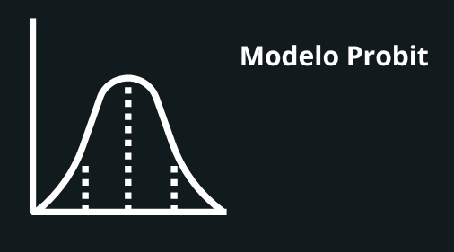

# Supuestos del modelo Probit

- La variable dependiente es binaria (dos categorías).
- Las variables independientes pueden ser continuas o categóricas.
- Los errores del modelo son independientes y siguen una distribución normal estándar.
- No hay multicolinealidad entre las variables independientes.

# Estimación del modelo Probit

El modelo Probit se estima utilizando el método de máxima verosimilitud. El software estadístico como R y Stata proporcionan funciones para estimar modelos Probit. La salida del modelo Probit incluye coeficientes de regresión, errores estándar, valores z y niveles de significancia.

- Los coeficientes de regresión del modelo Probit representan el cambio en la probabilidad de que el evento ocurra por una unidad de cambio en la variable independiente correspondiente.
- Un coeficiente de regresión positivo indica que un aumento en la variable independiente aumenta la probabilidad de que el evento ocurra. Y viceverza.

# Ejemplo de aplicación del modelo Probit

Ejemplo Práctico Predicción de la probabilidad de que un paciente desarrolle diabetes.

- Datos:
- Edad: 35 años.
- Sexo: Mujer.
- Historial médico: Presión arterial alta.
- Estilo de vida: Sedentaria, dieta rica en azúcares.

Pasos:

1- Definir la variable dependiente: ¿Desarrolla diabetes el paciente? (Sí/No)

2- Identificar las variables independientes: Edad, sexo, historial médico, estilo de vida.

3- Recopilar datos: Obtener información sobre las variables independientes para un grupo de pacientes.

4- Ajustar el modelo probit: Utilizar un software estadístico para ajustar el modelo probit a los datos.

5- Interpretar los resultados: El modelo probit proporcionará coeficientes para cada variable independiente. Estos coeficientes indican la relación entre cada variable independiente y la probabilidad de desarrollar diabetes.

6- Hacer predicciones: Utilizar el modelo probit para predecir la probabilidad de que un nuevo paciente desarrolle diabetes, en función de sus características individuales.

Para realizar el codigo se debe:

4. Interpretar los resultados summary(modelo_probit)

# Conclusiones

- El método probit es una herramienta poderosa para modelar decisiones binarias.
- El modelo Probit se puede implementar en software estadístico como R y Stata
- Su aplicación abarca múltiples campos y proporciona una manera precisa de entender relaciones binarias en los datos.
- Es importante verificar que se cumplan los supuestos del modelo Probit antes de realizar el análisis.